# Exercise 2 of “Big Data Analytics” (Winter Semester 2020/21)

# Task 2: Principal Component Analysis

Let’s recap the structure of the dataset:

```r
summary(iris)
```

```
  Sepal.Length    Sepal.Width     Petal.Length    Petal.Width          Species
 Min.   :4.300   Min.   :2.000   Min.   :1.000   Min.   :0.100   setosa    :50
 1st Qu.:5.100   1st Qu.:2.800   1st Qu.:1.600   1st Qu.:0.300   versicolor:50
 Median :5.800   Median :3.000   Median :4.350   Median :1.300   virginica :50
 Mean   :5.843   Mean   :3.057   Mean   :3.758   Mean   :1.199
 3rd Qu.:6.400   3rd Qu.:3.300   3rd Qu.:5.100   3rd Qu.:1.800
 Max.   :7.900   Max.   :4.400   Max.   :6.900   Max.   :2.500
```

As PCA is unsupervised, we don’t need the class variable.

```r
dataset <- iris[, colnames(iris) != "Species"]
```

## a) Computation

Computing PCA is just one function call:

```r
pca.fit <- prcomp(dataset, scale. = TRUE)
str(pca.fit)
```

```
List of 5
 $ sdev    : num [1:4] 1.708 0.956 0.383 0.144
 $ rotation: num [1:4, 1:4] 0.521 -0.269 0.58 0.565 -0.377 ...
  ..- attr(*, "dimnames")=List of 2
  .. ..$ : chr [1:4] "Sepal.Length" "Sepal.Width" "Petal.Length" "Petal.Width"
  .. ..$ : chr [1:4] "PC1" "PC2" "PC3" "PC4"
 $ center  : Named num [1:4] 5.84 3.06 3.76 1.2
  ..- attr(*, "names")= chr [1:4] "Sepal.Length" "Sepal.Width" "Petal.Length" "Petal.Width"
 $ scale   : Named num [1:4] 0.828 0.436 1.765 0.762
  ..- attr(*, "names")= chr [1:4] "Sepal.Length" "Sepal.Width" "Petal.Length" "Petal.Width"
 $ x       : num [1:150, 1:4] -2.26 -2.07 -2.36 -2.29 -2.38 ...
  ..- attr(*, "dimnames")=List of 2
  .. ..$ : NULL
  .. ..$ : chr [1:4] "PC1" "PC2" "PC3" "PC4"
 - attr(*, "class")= chr "prcomp"
```

We will use `sdev` later. `rotation` is the transformation matrix. `x` is the dataset after transformation. Furthermore, scaling information is stored in `center` (= means of attributes of original data) and `scale` (= standard deviations of attributes of original data).

You can alternatively get the transformed data with the `predict()` method:

```r
all(pca.fit$x == predict(pca.fit, newdata = dataset))
```

```
[1] TRUE
```

(The function can also be used to transform other data to the same basis.)

If we manually scale the data and multiply with the transformation matrix, we also get the same result:

```r
scaledDataset <- scale(dataset)
all(pca.fit$x == scaledDataset %*% pca.fit$rotation)
```

```
[1] TRUE
```

By the way, there also is a function `princomp()`, which computes PCA with a different algorithm. However, it is less preferable from the numeric perspective.

Regarding the normalization question: Features in your dataset might have different variances. From the summary above, we already see that the ranges are different for our features, though this does not directly say something about variance. We can also compute variance by applying the `var` function to each column of the dataset:

```r
sapply(dataset, var)
```

```
Sepal.Length  Sepal.Width Petal.Length  Petal.Width
   0.6856935    0.1899794    3.1162779    0.5810063
```

If one feature has a lot of variance, it gets more weight by PCA. However, we don’t want PCA to mainly capture the initial scaling of the data. PCA should consider the relationship between features. There also is a [StackExchange post](https://stats.stackexchange.com/questions/69157/why-do-we-need-to-normalize-data-before-principal-component-analysis-pca) on that issue.

## b) Explained Variance

The element `sdev` of our PCA result contains the standard deviation captured by the principle components. From that, we can easily determine the individual fraction of variance explained:

```r
pca.fit$sdev^2 / sum(pca.fit$sdev^2)
```

```
[1] 0.729624454 0.228507618 0.036689219 0.005178709
```

… and the accumulated fraction of variance explained:

```r
cumsum(pca.fit$sdev^2) / sum(pca.fit$sdev^2)
```

```
[1] 0.7296245 0.9581321 0.9948213 1.0000000
```

By the way, we get the same result if we call the `summary()` function:

```r
summary(pca.fit)
```

```
Importance of components:
                          PC1    PC2     PC3     PC4
Standard deviation     1.7084 0.9560 0.38309 0.14393
Proportion of Variance 0.7296 0.2285 0.03669 0.00518
Cumulative Proportion  0.7296 0.9581 0.99482 1.00000
```

The default `plot()` method is overridden for `prcomp` objects:

```r
plot(pca.fit)
```

[output not shown]

We can easily get a similar, though more ugly, result with a manual plot:

```r
plot(pca.fit$sdev^2, type = "h") # "h" creates vertical lines
```

[output not shown]

To make things more pretty, we can use `ggplot2`:

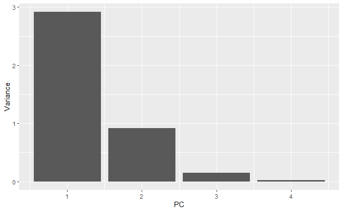

```r
library(ggplot2)
ggplot(data = data.frame(PC = 1:length(pca.fit$sdev), Variance = pca.fit$sdev^2)) +
  geom_bar(mapping = aes(x = PC, y = Variance), stat = "identity")
```

Regarding the implementation. we see that `ggplot2` is slightly less comfortable if you don’t already have a `data.frame`. Also, the bar plot usually counts values for each category itself (`stat = "count"`). If we want to supply the height of the bars directly, we have to set `stat` to `"identity"`.

## c) Feature Plots

Let’s have a look at the first two original features after scaling:

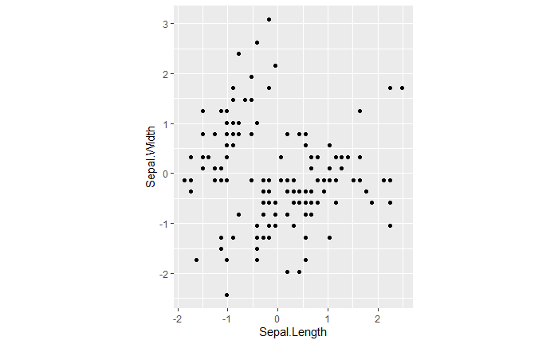

```r
library(ggplot2)
ggplot(data.frame(scaledDataset)) +
  geom_point(mapping = aes_string(x = colnames(scaledDataset)[1],
                                  y = colnames(scaledDataset)[2])) +
  coord_fixed()
```

The original but scaled features have the same variance. Some implementation details: First, don’t forget we are actually interested in the scaled version of the dataset. In the unscaled version, we would notice a difference in variance (you could try that out). Second, note that we pass the column names as strings instead of unquoted names (compare that to the last plotting call). Thus, we us `aes_string()` instead of `aes()`. Third, `coord_fixed()` allows us to fix the ratio between the axes units.

Now have a look at the first two principal components:

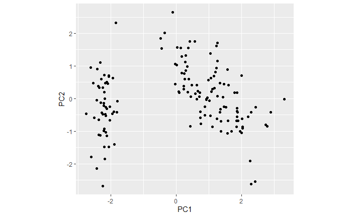

```r
library(ggplot2)
ggplot(data.frame(pca.fit$x)) +
  geom_point(mapping = aes_string(x = colnames(pca.fit$x)[1],
                                  y = colnames(pca.fit$x)[2])) +
  coord_fixed()
```

The plot after transformation exhibits an interesting structure. In general, PCA concentrates more variance in the first components, as we also computed above. Though the ranges of the first two principal components look rather similar here, note that PC2 scatters more regularly around the mean of zero. In contrast, PC1 has values scattered right of the mean and many points far on the left, which results in a higher variance.

## d) Feature Correlation

Fortunately, the function `cor()` supports a matrix and then computes the correlation between each pair of columns. Thus, we only need two one-liners of code.

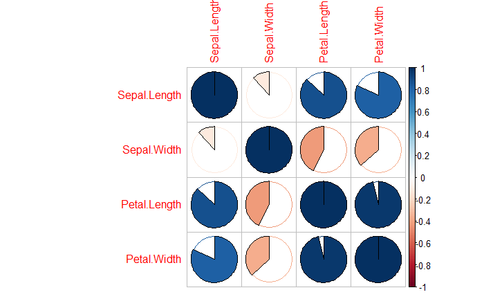

```r
library(corrplot)
corrplot(cor(scaledDataset), method = "pie")
```

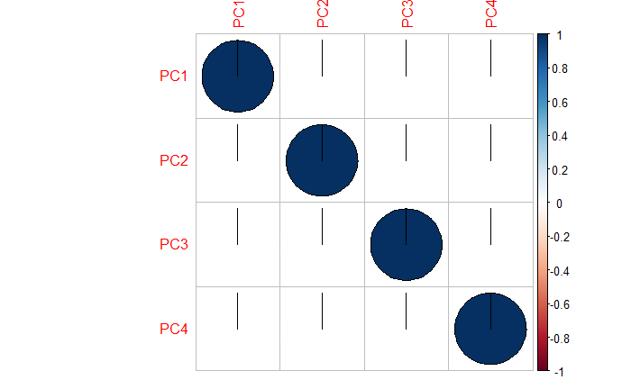

```r
corrplot(cor(pca.fit$x), method = "pie")
```

As you might remember from the lecture, principal components are orthogonal to each other, i.e.., their dot product is zero, i.e., their covariance is zero (considering their mean is also zero), i.e., their correlation is zero.

## e) MSE

Implementing the MSE function is quite easy if we use R’s built-in vectorized operations. The function even works for vectors as well as matrices.

```r
mse <- function(x1, x2) {
  return(mean((x1 - x2)^2))
}
```

## f) Reconstruction Error

First, as a simple test, we compute the MSE after re-transforming the (full) transformed dataset back. We can do this by multiplying the transformed dataset with the inverted transformation matrix:

```r
mse(pca.fit$x %*% solve(pca.fit$rotation), scaledDataset)
```

```
[1] 3.278194e-32
```

Though this is lossless (apart from numeric errors), you don’t save any memory – the transformed matrix is just as big as the original matrix. Thus, it makes sense just to store the first k components, which introduces some reconstruction error. What are the MSEs if we only keep one principal component?

```r
sapply(1:ncol(scaledDataset), function(i) {
  mse(pca.fit$x[, i] %o% solve(pca.fit$rotation)[i, ], scaledDataset)
})
```

```
[1] 0.2685730 0.7663491 0.9568887 0.9881891
```

We can clearly see that that the first components yield a lower reconstruction error. If we use more than one principal component, we can also see that the error decreases:

```r
sapply(1:ncol(scaledDataset), function(i) {
  if (i == 1) { # (outer) matrix-vector product
    mse(pca.fit$x[, 1] %o% solve(pca.fit$rotation)[1, ], scaledDataset)
  } else {# matrix-matrix product
    mse(pca.fit$x[, 1:i] %*% solve(pca.fit$rotation)[1:i, ], scaledDataset)
  }
})
```

```
[1] 2.685730e-01 4.158881e-02 5.144184e-03 3.278194e-32
```

Finally, for comparison, we simulate a transformation to each original feature and back from that. This means we keep one feature each and set the other columns to zero, their mean after scaling: (i.e., we rather do a projection than a transformation)

```r
sapply(1:ncol(scaledDataset), function(i) {
  transformedDataset <- scaledDataset
  transformedDataset[, -i] <- 0
  mse(transformedDataset, scaledDataset)
})
```

```
[1] 0.745 0.745 0.745 0.745
```

We can see that all features result in a rather high reconstruction error. The MSEs are the same due to our initial scaling to unit variance. By the way, there is a [StackExchange post](https://stats.stackexchange.com/questions/184603/in-pca-what-is-the-connection-between-explained-variance-and-squared-error) explaining the relationship between explained variance and reconstruction error. Roughly speaking, the proportion of explained variance equals one minus normalized error. Here, after normalization, each of the four features accounts for 25% of the variance. Thus, a reduction to one feature results in a (normalized) error of roughly 75%. It’s not exactly 75%, since normalization of the dataset was done with the sample standard deviation, i.e., dividing by n-1 instead of n. Thus, the MSE of replacing the whole dataset with zero is not exactly 1:

```r
mse(scaledDataset, 0)
```

```
[1] 0.9933333
```

Considering this, we get an explained variance of

```r
1 - 0.745 / mse(scaledDataset, 0)
```

```
[1] 0.25
```

for transforming to one feature, as we expected.